# Report BI 2021/2022

## Autores

- Turma: T62
- Grupo: G01/T62
- Autores
  - 20191393 Ana Catarina Quintans
  - 20190048 Carlos Chantre
  - 20181339 Pedro Amaral

## Marketing

Mostra-se um exemplo de código incluído neste ficheiro que produz o relatório!

### Perfil dos clientes

Apresentam-se algumas características dos clientes …

- **Rendimento**

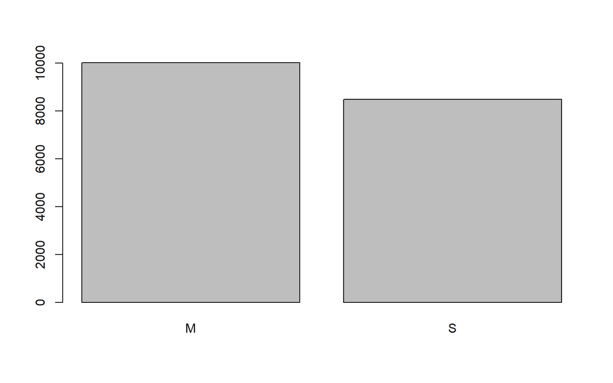

```r
load("customers.Rda")
plot(as.factor(customers$MaritalStatus))
```

- **Conclusões**

# Apêndice

## Dicionário do *data mart*

### 1. dimensão `calendar`

Esta dimensão corresponde ao calendário que contém informação relativa ao tempo em que são realizadas as transações comerciais.

- **ID**: Constituí-se como a Surrogate Key (chave artificial).
- **Date**: Contempla as datas ( dia, mês e ano) em que se realizaram transações.
- **DayNumberOfWeek**:Identifica numericamente o dia da semana.
- **DayName**: Identifica, à semelhança do anterior, mas textualmente.
- **MonthName**: Identifica o mês textualmente.
- **MonthNumberOfYear**: Identifica o mês numericamente.
- **DayNumberOfYear**: Identifica o dia do ano num formato de 365 dias.
- **WeekNumberOfYear**: Identifica a semana numericamente.
- **CalendarQuarter**: Refere o trimestre em que se realizou a transação.
- **CalendarYear**: Refere o ano.
- **DayNumberOfMonth**: Identifica o dia do mês.

### 2. dimensão `product`

- **ProductKey**: Chave que identifica o produto (numeric).
- **ProductSubCategoryKey**: Chave que identifica a sub-categoria do produto (numeric).
- **ProductName**: Nome do produto.
- **StandarCost**: Custo de fabrico.
- **Color**: Cor do produto.
- **SafetyStockLevel**: Minimo que a empresa necessita de ter em stock.
- **ListPrice**: Preço de venda dos produtos.
- **Size**: Tamanho do produto.
- **DaysToManufacture**: Dias para produzir.
- **DealerPrice**: Preço de venda para revendedores.
- **Class**: Classe de produto.
- **ModelName**: Nome do modelo do produto.
- **Description**: Descrição do produto.
- **Status**: Disponibilidade para vender.
- **SubCategory**: Sub-categoria.
- **Category**: Categoria.
- **StartDate**: Desde quando está disponível os produtos para vender.
- **EndDate**: Quando é que os produtos deixaram de estar disponiveis para venda.

### 3. dimensão `productCategory`

- **ProductCategoryKey**: Chave que identifica univocamente o produto.
- **EnglishProductCategoryName**: Nome da categoria do produto em Inglês.
- **SpanishProductCategoryName**: Nome da categoria do produto em Espanhol.
- **FrenchProductCategoryName**: Nome da categoria do produto em Francês.

### 4. dimensão `productSubCategory`

- **ProductCategoryKey**: Chave que identifica univocamente o produto.
- **ProductSubCategoryKey**: Chave que identifica a sub-categoria do produto (numeric).
- **EnglishProductSubCategoryName**: Nome da sub-categoria do produto em Inglês.
- **SpanishProductSubCategoryName**: Nome da sub-categoria do produto em Espanhol.
- **FrenchProductSubCategoryName**: Nome da sub-categoria do produto em Francês.

### 5. dimensão `customers`

- **CustomerKey**: Chave que identifca os cliente.
- **GeographyKey**: Chave que indentifica a cidade/código-postal dos clientes.
- **Name**: Nomes dos clientes.
- **BirthDate**: Data de nascimento dos clientes.
- **MaritalStatus**: Estado-civil dos clientes.
- **Gender**: Genero dos Clientes.
- **YearlyIncome**: Nível de rendimento dos clientes.
- **NumberChildrenAtHome**: Número de crianças em casa.
- **Occupation**: Profissão dos clientes.
- **HouseOwnerFlag**: Se o cliente é proprietário ou não de casa. (factor?)
- **NumberCarsOwned**: Quantos carros possuem.
- **AddressLine**: Morada dos clientes.
- **Phone**: Número de telefone dos clientes.
- **DateFirstPurchase**: Data da primeira compra.

### 6. dimensão `territory`

- **TERRITORY DIMENSION**: Dimensão do território.
- **Territory Key**: Chave que identifica o território.
- **Region**: Região.
- **Country**: Pais.
- **Group**: Região económica.